# Sample output

AD

9/30/2024

# Assessment summary

Input data include:  
-5 independent variables:device, sensor, mode, cleaning, ionic strength  
-3 dependent variables: gm, Vt, pH response

### *Primary objective: Determine if there is a significant difference between control and experimental group for each one of the dependent variables

### * Secondary objective 1: Determine which one of the independent variables is dominating that difference for the dependent variables.

### * Secondary objective 2: Determine if there is a significant difference in pH response for control vs experimental groups and if so which one of the independent variables induces that difference between the two groups.

```r
inpdf<-read.csv("example data.csv")
library(dplyr)
library(tidyr)
library(tidyverse)
library(ggplot2)
library(tableone)
library(grid)
library(gridExtra)
```

#### Prepare input data

```r
gsub("experiemental","experimental",inpdf$group)->inpdf$group
as.factor(inpdf$group)->inpdf$group
myVars<-c("gm","Vt","pH.response")
summary_desc <- CreateTableOne(vars = myVars, strata = "group" , data = inpdf)
```

## Primary objective

#### Summary statistics for dependent variables

```r
print(summary_desc)
```

```
##                          Stratified by group
##                           control          experimental     p      test
##   n                            56               32
##   gm (mean (SD))          2719.85 (275.75) 2749.38 (123.52)  0.568
##   Vt (mean (SD))             0.17 (0.07)      0.14 (0.07)    0.073
##   pH.response (mean (SD))   55.16 (2.36)     48.49 (5.05)   <0.001
```

Answer to primary objective:

As shown under the summary statistics above for the dependent variables gm, VT and pH response, only the difference in pH response between groups is statistically significant (p <0.05). Vt is nearing significance with means lower for both pH response and Vt in the experimental group compared to the control.

## Secondary objectives 1 and 2

```r
A<-ggplot(inpdf, aes(group,pH.response,fill=group))+geom_boxplot()
B<-ggplot(inpdf, aes(group,pH.response,fill=group))+geom_violin()
C<-ggplot(inpdf, aes(sensor, fill =group))+geom_bar(position="identity", stat="count")
D<-ggplot(inpdf, aes(as.factor(device), fill =group))+geom_bar(position="identity", stat="count")+xlab("device")
catVarsd<-c("device","sensor","mode","cleaning","ionic.strength")
summary_desc <- CreateTableOne(vars = catVarsd, strata = "group",factorVars = catVarsd, data = inpdf)
```

#### Summary statistics for independent variables

```r
print(summary_desc)
```

```
##                           Stratified by group
##                            control    experimental p      test
##   n                        56         32
##   device (%)                                        0.001
##      1                     16 (28.6)   0 ( 0.0)
##      2                      8 (14.3)   0 ( 0.0)
##      4                     12 (21.4)  12 (37.5)
##      5                     12 (21.4)  12 (37.5)
##      6                      8 (14.3)   8 (25.0)
##   sensor (%)                                       <0.001
##      F4                     4 ( 7.1)  16 (50.0)
##      F5                     4 ( 7.1)  16 (50.0)
##      S2                    24 (42.9)   0 ( 0.0)
##      S5                    24 (42.9)   0 ( 0.0)
##   mode = up (%)            28 (50.0)  16 (50.0)     1.000
##   cleaning = Yes (%)       28 (50.0)  20 (62.5)     0.363
##   ionic.strength = Low (%) 32 (57.1)  20 (62.5)     0.790
```

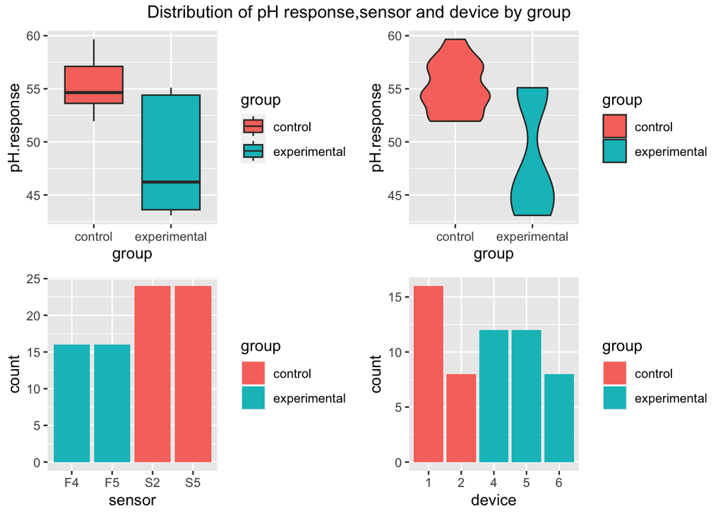

```r
grid.arrange(A,B,C,D,ncol=2,top = "Distribution of pH response,sensor and device by group ")
```